# 0115

## Working with random samples

Samples from random variables are central to Bayesian data analysis. As we discussed in class, the exact posterior distribution for a given model is most often difficult or impossible to calculate. But it is relatively straightforward to calculate a non-normalized function that is *proportional* to the exact posterior. For decades, researchers have been coming up with unbelievably clever ways to use that non-normalizied posterior to generate random samples from the exact posterior. The upshot of this is that as statisticians, we can say just about anything we want to about a distribution using just a large sample from the posterior.

Start by taking a sample of 2,000 values from a Beta distribution with parameters $\alpha=2,\beta=50$.

```r
a <- 2
b <- 50
s <- rbeta(2000,a,b)
# the head() function shows you the first several values from a large vector or table
head(s)
```

1. 0.0396615830041653

2. 0.00852742247651381

3. 0.0428840186980457

4. 0.0752858379309991

5. 0.0597257956720119

6. 0.0239700145839133

(As a side note, the Beta distribution is the exact posterior for a binomial model like our unemployment model if $p$ has a Beta prior. Because $\mathrm{Beta}(1,1)$ is just the uniform distribution, $\mathrm{Beta}(2,50)$ is the posterior with a uniform prior if we have seen exactly 49 employed people and 1 unemployed person.)

Use a histogram to get a sense of the shape of the distribution.

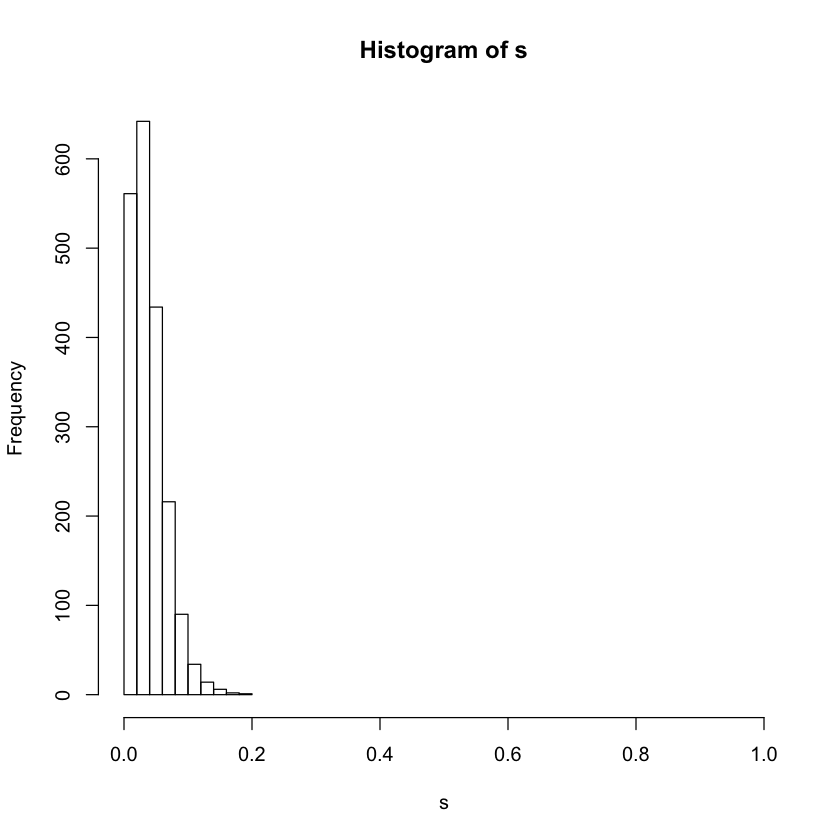

```r
# the hist() function tries to make a good guess about the number of
# bins to use, but you can give it a hint giving it a `breaks` argument.
# Try increasing breaks to see how it starts to be less useful.
hist(s,xlim=c(0,1), breaks=10)
```

Another way to see the overall shape of a distribution is using R's `density()` function, which takes a random sample from a continuous distribution and tries to construct a 'smooth' probability density function from it. By default `density()` assumes the sample is from an *unbounded* continuous random variable. If you have strict upper and lower bounds like we do (Beta is bounded in [0,1]), it is important to let the function know this information. (What happens if you leave off the `from` and `to` arguments in the code below?)

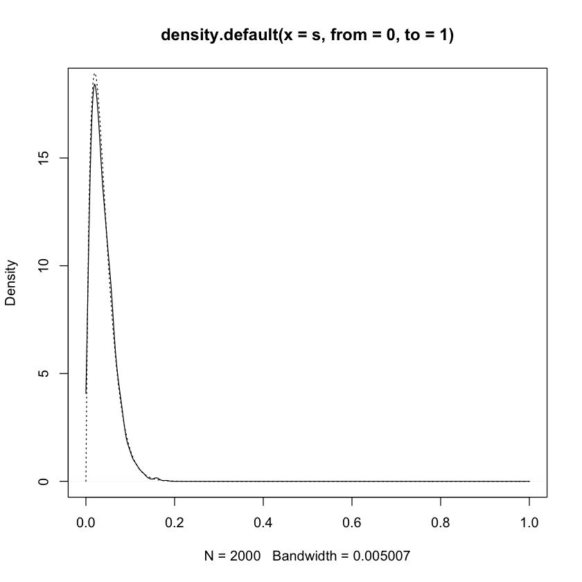

```r
d <- density(s,from=0,to=1)
plot(d)
# since we know the exact distribution in this case,
# overlay it for comparison
lines(d$x,dbeta(d$x,a,b),lty=3)
```

Caclulating the mean and median of the sample is simple, but calculating the mode is a little more complicated

```
      mean     median       mode
0.03825265 0.03238311 0.01956947
```

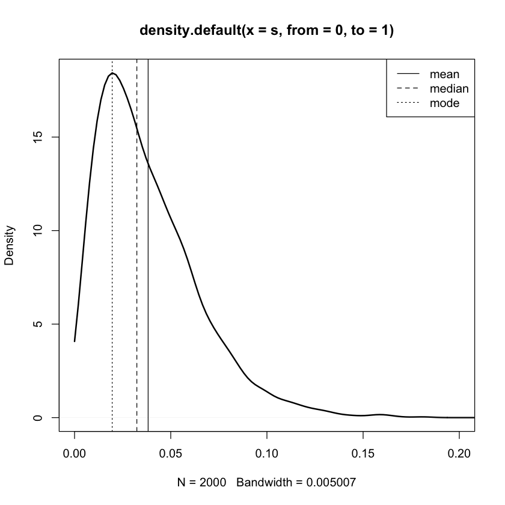

```r
# R has built in functions for mean and median
smean <- mean(s)
smedian <- median(s)
# we can approximate the mode by looking for the value
# of p that maximizes the density we calculated before
smode <- d$x[which.max(d$y)]

centers <- c(smean,smedian,smode)
names(centers) <- c('mean','median','mode')
print(centers)

# visualize these (zooming in on the right side of the
# density for visual clarity)
plot(d,xlim=c(0,0.2),lwd=2)
abline(v=centers,lty=c(1,2,3))
legend('topright',legend=names(centers),lty=c(1,2,3))
```

We can use R's `quantile` function to easily calculate percentile intervals. We should expect the percentile interval to be approximately centered around the median.

```
       25%        75%
0.01850315 0.05259500
```

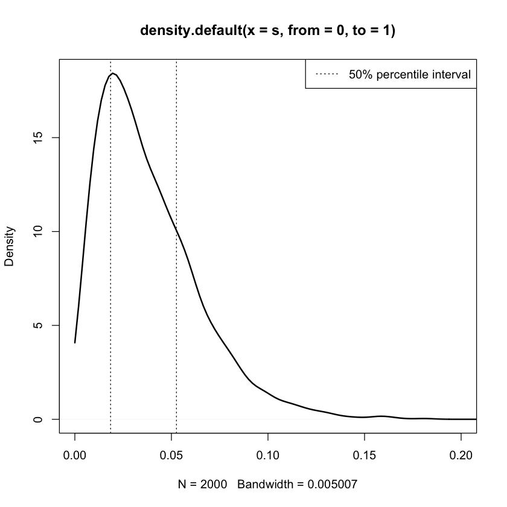

```r
# for a 50% credible interval, we want to leave 25% on either end.
# (This function just puts the sample in order and finds the values that
# are 25% and 75% of the way through the ordered list.)
perc <- quantile(s,probs=c(0.25,0.75))
print(perc)
plot(d,xlim=c(0,0.2),lwd=2)
abline(v=perc,lty=3)
legend('topright',legend='50% percentile interval',lty=3)
```

The highest posterior density interval is more complex, but we can use the `HPDI()` function from the `rethinking` package. (Note: this function is just an easier way to call the `HPDinterval()` function in the `coda` package). We should expect the HPDI estimate to be approximately centered around the mode, and so a little to the left of the percentile interval.

[output not shown]

```
       |0.5        0.5|
0.006426002 0.035192067
```

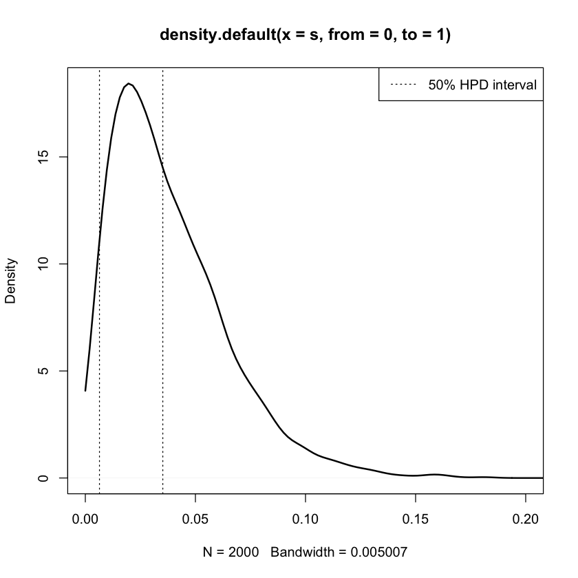

```r
library(rethinking)
hpdi <- HPDI(s,.5)
print(hpdi)
plot(d,xlim=c(0,0.2),lwd=2)
abline(v=hpdi,lty=3)
legend('topright',legend='50% HPD interval',lty=3)
```

We can also easily use the sample to assign probabilities to particular research questions. What is the posterior probability that the unemployment rate is higher than 0.1? About 3%.

```r
mean(s>0.1)
```

0.0285

### Drawing samples from a grid approximation

It is possible to approximate samples from a posterior using the grid approximations we have been working with. First let's construct a grid approximation for the situation described above (49 employed people, 1 unemployed person), which corresponds to a sample size of 50 and a binomial count of just 1.

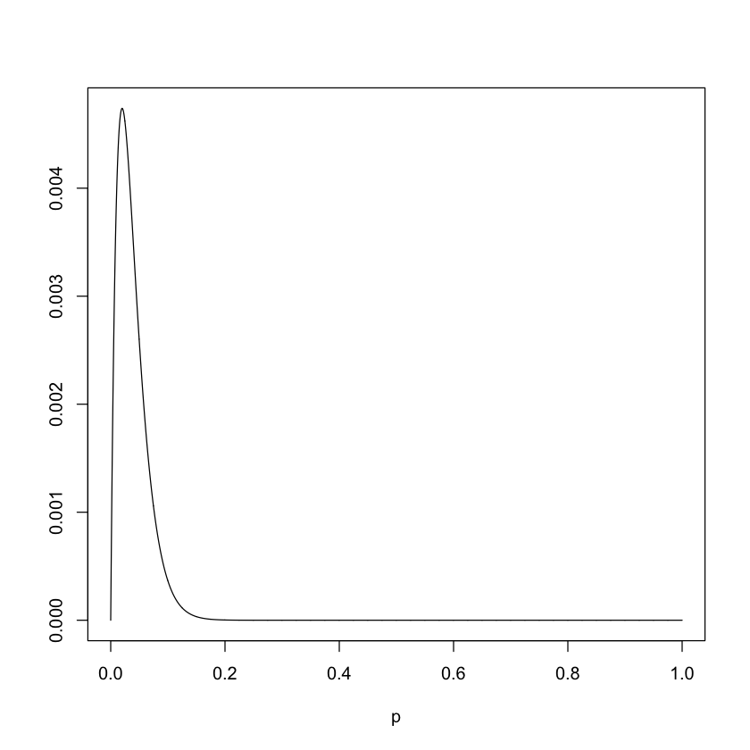

```r
# make a large grid
n_grid <- 4000
grid <- seq(from=0,to=1,length.out=n_grid)

# make the data
ssize <- 50
n_unemp <- 1

# prior and likelihood
prior <- dunif(grid)
lik <- dbinom(n_unemp,size=ssize,prob=grid)

# posterior
post <- prior*lik
post <- post/sum(post)

plot(grid,post,type='l',xlab='p',ylab='')
```

The grid approximation works by constructing a discrete distribution that matches the contininous distribution that is our posterior. This means we can use R's `sample()` function to take a random discrete sample.

```r
# sample the points along grid with probability defined by `post`
# It is vital that you set `replace=TRUE` here.
s_grid <- sample(grid,size=2000,prob=post,replace=TRUE)
```

Now let's calculate some descriptives to see how they compare.

```r
gmean <- mean(s_grid)
gmedian <- median(s_grid)
d_grid <- density(s_grid,from=0,to=1)
gmode <- d_grid$x[which.max(d_grid$y)]

centers_grid <- c(gmean,gmedian,gmode)
print(cbind(centers,centers_grid))
```

```
          centers centers_grid
mean   0.03825265   0.03881483
median 0.03238311   0.03300825
mode   0.01956947   0.02152642
```

```r
perc_grid <- quantile(s_grid,probs=c(0.25,0.75))
print(perc)
print(perc_grid)
```

```
       25%        75%
0.01850315 0.05259500
       25%        75%
0.01950488 0.05201300
```

```r
hpdi_grid <- HPDI(s_grid,.5)
print(hpdi)
print(hpdi_grid)
```

```
       |0.5        0.5|
0.006426002 0.035192067
      |0.5       0.5|
0.01050263 0.03825956
```

```r
print(mean(s>0.1))
print(mean(s_grid>0.1))
```

```
[1] 0.0285
[1] 0.0315
```